# Identify Fraud from Enron Email Project

## 1. Summarize for us the goal of this project and how machine learning is useful in trying to accomplish it. As part of your answer, give some background on the dataset and how it can be used to answer the project question. Were there any outliers in the data when you got it, and how did you handle those?

The goal of this project is to analyze the financial and email dataset of Enron company, whic is publicly made by US Federal Energy Regulatory Commission during its investigation of Enron company and to create a model that predicts an individual which we call a Person of Interest (POI). The corpus contains email and financial data of 146 people, most of which were senior management of Enron.

> The dataset contains 146 people records with 18 POI and 128 Non-POI, where the features found was 21 in total . The dataset contains missing values and some outliers we will see next: The outliers are:
> - TOTAL: Added data to everything and it doesn't represent an individual.
> - THE TRAVEL AGENCY IN THE PARK: This was in the dataset as a name of individual.
> - LOCKHARD EUGENE E: it has no data only NaN.

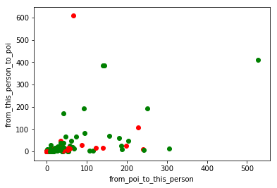

```python
from IPython.display import Image
Image("/Users/Abdulaziz/Desktop/p1.png", width ="400")
```

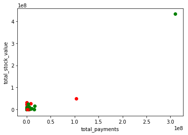

```python
Image("/Users/Abdulaziz/Desktop/p2.png", width ="400")
```

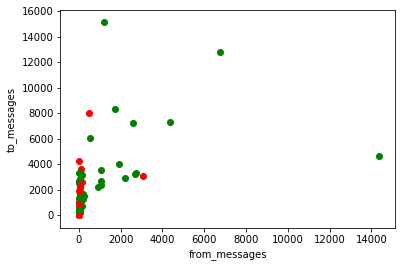

```python
Image("/Users/Abdulaziz/Desktop/p3.png", width ="400")
```

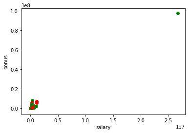

```python
Image("/Users/Abdulaziz/Desktop/p4.png", width ="400")
```

## 2. What features did you end up using in your POI identifier, and what selection process did you use to pick them? Did you have to do any scaling? Why or why not?

> GridSearchCV is a way of systematically working through multiple combinations of parameter tunes, cross-validating as it goes to determine which tune gives the best performance.

> I used the fit function to try all the parameter combinations, and returns a fitted classifier that's automatically tuned to the optimal parameter combination after that we can access the parameter values via best_params

> Selected features and their scores: {'exercised_stock_options': 24.815079733218194, 'total_stock_value': 24.182898678566879, 'bonus': 20.792252047181535, 'salary': 18.289684043404513, 'fraction_to_poi': 16.409712548035788, 'deferred_income': 11.458476579280369, 'long_term_incentive': 9.9221860131898225, 'restricted_stock': 9.2128106219771002, 'total_payments': 8.7727777300916792, 'shared_receipt_with_poi': 8.589420731682381, 'loan_advances': 7.1840556582887247, 'expenses': 6.0941733106389453}

> I scaled features using preprocessing.MinMaxScaler(). If we do not normalize the features, some machine learning algorithms might not work properly.